# Simulation from a user-specified, ODE-based PK model

### User-defined PK functions using the tci package

The `tci` package provides closed-form solutions for 1-, 2-, 3-, and 3-compartment with effect-site PK models based on solutions described and code provided in Abuhelwa, Foster, and Upton (2015). It does not, however, include an ordinary differential equation (ODE) solver as many other R packages do, including [mrgsolve](https://mrgsolve.github.io/), [PKPDsim](http://pkpdsim.ronkeizer.com/), and RxODE. `tci` package functions can nonetheless be applied to models from these packages through the creation of user-defined PK functions.

User-defined PK functions should be created to return concentrations at a vector of time points under a continuous infusion and should be assigned S3 class “pkmod.”

To illustrate, we create an example two-compartment model based on ODEs is illustrated using the `PKPDsim` R package(Keizer 2017) which can be installed from GitHub.

```r
devtools::install_github("ronkeizer/PKPDsim") # install PKPDsim
```

Using `PKPDsim` syntax, a model can be specified.

```r
library(tci)
library(PKPDsim)

# define custom two-compartment model from PKPDsim
pk2 <- new_ode_model(code = "
  dAdt[1] = -(CL/V)*A[1] - (Q/V)*A[1] + (Q/V2)*A[2]
  dAdt[2] = -(Q/V2)*A[2] + (Q/V)*A[1]

", parameters = c("CL","V","Q","V2")
)
```

A wrapper function is then created to take as arguments a time at which to evaluate the PK model (`tm`), an infusion rate (`kR`), PK model parameters (`pars`), initial concentrations (`init`), and an infusion starting time (`inittm`). The starting time is used by functions in `tci` that iteratively calculate concentrations from a series of infusions. Within this function, the `PKPDsim` functions “new_regimen” and “sim” are used to specify and predict from an infusion schedule.

```r
# wrapper function to evaluate pk2 in format used by tci
pkmod2cpt_ode <- function(tm, kR, pars,
                          pkm = pk2,
                          init = c(0,0),
                          inittm = 0){

  # start times at 0 and use uppercase names for PKPDsim functions
  tm <- tm - inittm
  names(pars) <- toupper(names(pars))
  # pass parameters as list
  pars <- sapply(pars, as.list)

  # dosing regimen - PKPDsim function
  reg <- new_regimen(
    amt = kR,
    times = 0,
    type = "infusion",
    t_inf = max(tm)
  )

  vols <- unlist(pars[c("V","V2")])

  # predict amounts
  dat <- sim(
    ode = pk2,
    parameters = pars,
    regimen = reg,
    A_init = init*vols, # init specifies concentrations
    t_obs = tm
  )

  # return concentrations with compartments in rows and times in columns
  datw <-reshape(dat[dat$comp %in% c(1,2),], idvar = "t",
                 v.names = "y",
                 timevar = "comp",
          direction = "wide")

  cons <- t(datw[,c("y.1","y.2")]) / vols

  rownames(cons) <- colnames(cons) <- NULL
  return(cons)
}
class(pkmod2cpt_ode) <- "pkmod"
```

For use with the `tci` package, the user-defined PK function should have class “pkmod”. We can now assign parameter values and predict from this model as we would any other.

```r
# create dose
dose <- create_intvl(
  as.matrix(cbind(time = c(0.5,4,4.5,10),
                  infrt = c(100,0,100,0)))
)

# model parameters
pars_2cpt <- c(CL = 15, V = 10, Q = 10, V2 = 20)

# predict concentrations
predict(pkmod2cpt_ode,
        pars = pars_2cpt,
        inf = dose,
        tms = c(1,2,3))
```

```
#>      time        c1        c2
#> [1,]    1 2.0169620 1.3763824
#> [2,]    2 0.6505072 1.2432245
#> [3,]    3 0.4362025 0.9570632
```

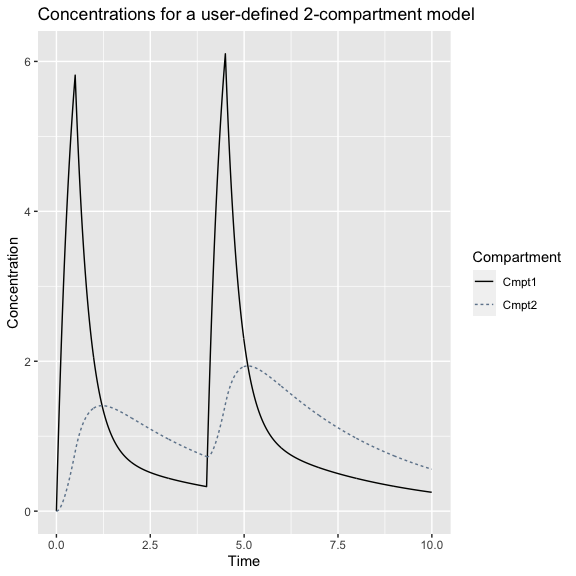

```r
# plot concentrations
plot(pkmod2cpt_ode,
     pars = pars_2cpt,
     inf = dose,
     title = "Concentrations for a user-defined 2-compartment model")
```

We can also apply TCI algorithms to calculate infusion schedules required to reach designated targets with the user-defined model.

```r
# target concentration = 1 for times 0 - 5
# target concentration = 2 for times 5 - 10
tci_times <- c(0,5,10)
tci_targets <- c(1,2,2)

# plasma-targeting
inf_3cpt_plasma <- tci(Ct = tci_targets,
                       tms = tci_times,
                       pkmod = pkmod2cpt_ode,
                       pars = pars_2cpt,
                       tci_alg = "plasma")
# print infusion schedule
head(inf_3cpt_plasma)
```

```
#>          infrt     begin       end        dt Ct c1_start   c2_start c1_end
#> [1,] 12.200358 0.0000000 0.1666667 0.1666667  1        0 0.00000000      1
#> [2,]  4.025604 0.1666667 0.3333333 0.1666667  1        1 0.04325747      1
#> [3,]  3.903759 0.3333333 0.5000000 0.1666667  1        1 0.11966984      1
#> [4,]  3.791645 0.5000000 0.6666667 0.1666667  1        1 0.18997937      1
#> [5,]  3.688485 0.6666667 0.8333333 0.1666667  1        1 0.25467347      1
#> [6,]  3.593565 0.8333333 1.0000000 0.1666667  1        1 0.31420063      1
#>          c2_end
#> [1,] 0.04325747
#> [2,] 0.11966984
#> [3,] 0.18997937
#> [4,] 0.25467347
#> [5,] 0.31420063
#> [6,] 0.36897353
```

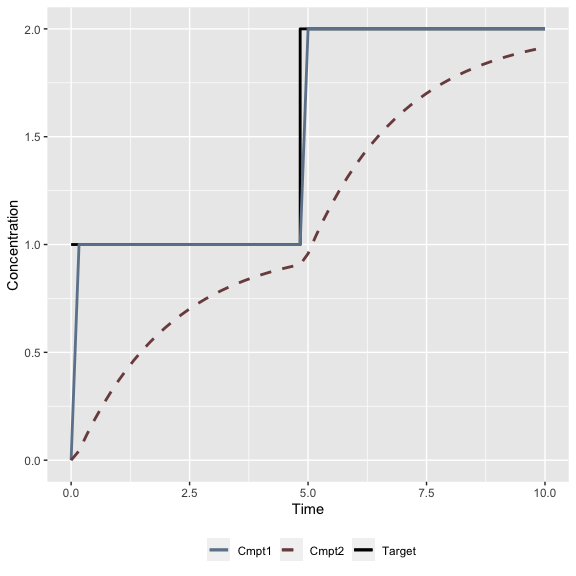

```r
# plot infusion schedule
plot(inf_3cpt_plasma)
```

### References

Abuhelwa, Ahmad Y., David J R Foster, and Richard N. Upton. 2015. “ADVAN-style analytical solutions for common pharmacokinetic models.” *Journal of Pharmacological and Toxicological Methods* 73: 42–48. https://doi.org/10.1016/j.vascn.2015.03.004.

Keizer, Ron. 2017. *PKPDsim: Simulate Ode Models*.